# E-Commerce Sales and Customer Analysis

##### Author: Raahul John Alex

##### Tools Used: Python, Pandas, Matplotlib, Jupyter Notebook

## Project Overview

This project analyzes an e-commerce retail dataset to understand sales performance, customer behavior and product trends. The goal is to extract business insights that could help decision-makers improve revenue, optimize product strategy and better understand customer segments.

## Business Problem

Retail companies generate large volumes of transactional data. However, without proper analysis, it becomes difficult to understand which products drive revenue, which regions perform best, and how customers contribute to sales.

This analysis aims to answer several key business questions:

- What is the total revenue and profit generated?
- Which regions generate the highest sales?
- Which product categories perform best?
- Who are the top customers?
- How do sales trends evolve over time?

Understanding these patterns can help businesses improve sales strategy and customer targeting.

```python
import pandas as pd
import numpy as np
import matplotlib.pyplot as plt
```

## Load Dataset

### Dataset Description

The dataset contains historical order information from an e-commerce retailer. Each row represents an individual product sold within an order.

Key variables include:

- Order date
- Customer information
- Product category
- Sales value
- Profit
- Region

```python
df = pd.read_csv("Sales_Cleaned_Data.csv", encoding="latin1")

df.head()
```

|  | Row ID | Order ID | Order Date | Ship Date | Ship Mode | Customer ID | Customer Name | Segment | Country | City | ... | Postal Code | Region | Product ID | Category | Sub Category | Product Name | Sales | Quantity | Discount | Profit |
| --- | --- | --- | --- | --- | --- | --- | --- | --- | --- | --- | --- | --- | --- | --- | --- | --- | --- | --- | --- | --- | --- |
| 0 | 1 | CA-2016-152156 | 11-08-2016 | 11-11-2016 | Second Class | CG-12520 | Claire Gute | Consumer | United States | Henderson | ... | 42420 | South | FUR-BO-10001798 | Furniture | Bookcases | Bush Somerset Collection Bookcase | 261.96 | 2 | 0.0 | 41.91 |
| 1 | 2 | CA-2016-152156 | 11-08-2016 | 11-11-2016 | Second Class | CG-12520 | Claire Gute | Consumer | United States | Henderson | ... | 42420 | South | FUR-CH-10000454 | Furniture | Chairs | Hon Deluxe Fabric Upholstered Stacking Chairs,... | 731.94 | 3 | 0.0 | 219.58 |
| 2 | 3 | CA-2016-138688 | 06-12-2016 | 06-16-2016 | Second Class | DV-13045 | Darrin Van Huff | Corporate | United States | Los Angeles | ... | 90036 | West | OFF-LA-10000240 | Office Supplies | Labels | Self-Adhesive Address Labels for Typewriters b... | 14.62 | 2 | 0.0 | 6.87 |
| 3 | 4 | US-2015-108966 | 10-11-2015 | 10-18-2015 | Standard Class | SO-20335 | Sean O'Donnell | Consumer | United States | Fort Lauderdale | ... | 33311 | South | FUR-TA-10000577 | Furniture | Tables | Bretford CR4500 Series Slim Rectangular Table | 957.58 | 5 | 0.5 | -383.03 |
| 4 | 5 | US-2015-108966 | 10-11-2015 | 10-18-2015 | Standard Class | SO-20335 | Sean O'Donnell | Consumer | United States | Fort Lauderdale | ... | 33311 | South | OFF-ST-10000760 | Office Supplies | Storage | Eldon Fold 'N Roll Cart System | 22.37 | 2 | 0.2 | 2.52 |

5 rows × 21 columns

## Dataset Shape

### Dataset Size

To understand the scale of the dataset, we first examine the number of rows and columns.

```python
df.shape
```

```
(9994, 21)
```

The dataset contains **9994 rows** and **21 columns**, representing thousands of sales transactions.

## Column Information

### Data Structure

Understanding the data types helps determine which variables represent dates, numeric values, or categorical information.

```python
df.info()
```

```
<class 'pandas.core.frame.DataFrame'>
RangeIndex: 9994 entries, 0 to 9993
Data columns (total 21 columns):
 #   Column         Non-Null Count  Dtype
---  ------         --------------  -----
 0   Row ID         9994 non-null   int64
 1   Order ID       9994 non-null   object
 2   Order Date     9994 non-null   object
 3   Ship Date      9994 non-null   object
 4   Ship Mode      9994 non-null   object
 5   Customer ID    9994 non-null   object
 6   Customer Name  9994 non-null   object
 7   Segment        9994 non-null   object
 8   Country        9994 non-null   object
 9   City           9994 non-null   object
 10  State          9994 non-null   object
 11  Postal Code    9994 non-null   int64
 12  Region         9994 non-null   object
 13  Product ID     9994 non-null   object
 14  Category       9994 non-null   object
 15  Sub Category   9994 non-null   object
 16  Product Name   9994 non-null   object
 17  Sales          9994 non-null   float64
 18  Quantity       9994 non-null   int64
 19  Discount       9994 non-null   float64
 20  Profit         9994 non-null   float64
dtypes: float64(3), int64(3), object(15)
memory usage: 1.6+ MB
```

## Clean Column Names

### Cleaning Column Names

To make the dataset easier to work with in Python, column names are standardized by converting them to lowercase and replacing spaces with underscores.

```python
df.columns = (
    df.columns
    .str.strip()
    .str.lower()
    .str.replace("-", "_", regex=False)
    .str.replace(" ", "_", regex=False)
)

df.columns
```

```
Index(['row_id', 'order_id', 'order_date', 'ship_date', 'ship_mode',
       'customer_id', 'customer_name', 'segment', 'country', 'city', 'state',
       'postal_code', 'region', 'product_id', 'category', 'sub_category',
       'product_name', 'sales', 'quantity', 'discount', 'profit'],
      dtype='object')
```

## Convert Date Columns

### Date Conversion

The order and shipping dates are converted into datetime format to enable time-based analysis.

```python
df["order_date"] = pd.to_datetime(df["order_date"])
df["ship_date"] = pd.to_datetime(df["ship_date"])
```

## Missing Values

### Missing Value Analysis

Missing values can affect analysis results. We check for any null values in the dataset.

```python
df.isnull().sum()
```

```
row_id           0
order_id         0
order_date       0
ship_date        0
ship_mode        0
customer_id      0
customer_name    0
segment          0
country          0
city             0
state            0
postal_code      0
region           0
product_id       0
category         0
sub_category     0
product_name     0
sales            0
quantity         0
discount         0
profit           0
dtype: int64
```

## Feature Engineering

### Creating Time-Based Features

Additional features such as year, month, and order month are created to support time-based analysis.

```python
df["year"] = df["order_date"].dt.year
df["month"] = df["order_date"].dt.month
df["order_month"] = df["order_date"].dt.to_period("M").astype(str)
```

## Overall Business Performance

### Overall Sales Performance

We begin by calculating total sales, profit, and number of orders to understand overall business performance.

```python
total_sales = df["sales"].sum()
total_profit = df["profit"].sum()
total_orders = df["order_id"].nunique()
total_customers = df["customer_id"].nunique()

print("Total Sales:", total_sales)
print("Total Profit:", total_profit)
print("Total Orders:", total_orders)
print("Total Customers:", total_customers)
```

```
Total Sales: 2297201.07
Total Profit: 286397.79
Total Orders: 5009
Total Customers: 793
```

## Regional Performance

### Sales by Region

Understanding regional performance helps identify high-performing markets.

```python
sales_by_region = df.groupby("region")["sales"].sum().sort_values(ascending=False)

sales_by_region
```

```
region
West       725457.93
East       678781.36
Central    501239.88
South      391721.90
Name: sales, dtype: float64
```

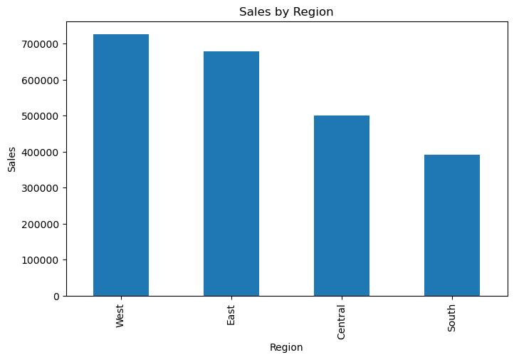

```python
sales_by_region.plot(kind="bar", figsize=(8,5))
plt.title("Sales by Region")
plt.xlabel("Region")
plt.ylabel("Sales")
plt.show()
```

## Monthly Sales Trend

### Sales Trend Over Time

Analyzing sales trends over time helps identify seasonality and growth patterns.

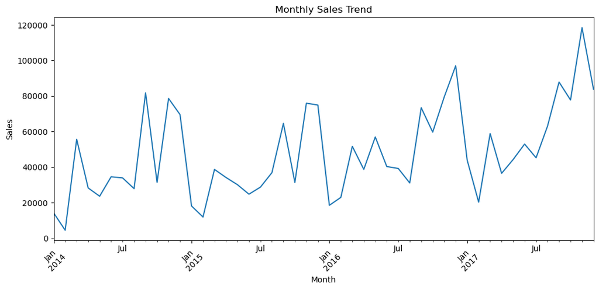

```python
monthly_sales = df.groupby(df["order_date"].dt.to_period("M"))["sales"].sum()

monthly_sales.plot(figsize=(12,5))
plt.title("Monthly Sales Trend")
plt.xlabel("Month")
plt.ylabel("Sales")
plt.xticks(rotation=45)
plt.show()
```

## Product Category Performance

### Category Performance

This section evaluates how product categories contribute to overall sales and profitability.

```python
category_sales = df.groupby("category")[["sales","profit"]].sum()

category_sales
```

| category | sales | profit |
| --- | --- | --- |
| Furniture | 741999.98 | 18451.25 |
| Office Supplies | 719046.99 | 122490.88 |
| Technology | 836154.10 | 145455.66 |

## Top Performing Products

### Product Performance Analysis

Understanding which products drive revenue helps businesses optimize product offerings and inventory management.

```python
top_products = (
    df.groupby("product_name")["sales"]
    .sum()
    .sort_values(ascending=False)
    .head(10)
)

top_products
```

```
product_name
Canon imageCLASS 2200 Advanced Copier                                          61599.83
Fellowes PB500 Electric Punch Plastic Comb Binding Machine with Manual Bind    27453.38
Cisco TelePresence System EX90 Videoconferencing Unit                          22638.48
HON 5400 Series Task Chairs for Big and Tall                                   21870.57
GBC DocuBind TL300 Electric Binding System                                     19823.48
GBC Ibimaster 500 Manual ProClick Binding System                               19024.50
Hewlett Packard LaserJet 3310 Copier                                           18839.68
HP Designjet T520 Inkjet Large Format Printer - 24" Color                      18374.90
GBC DocuBind P400 Electric Binding System                                      17965.07
High Speed Automatic Electric Letter Opener                                    17030.31
Name: sales, dtype: float64
```

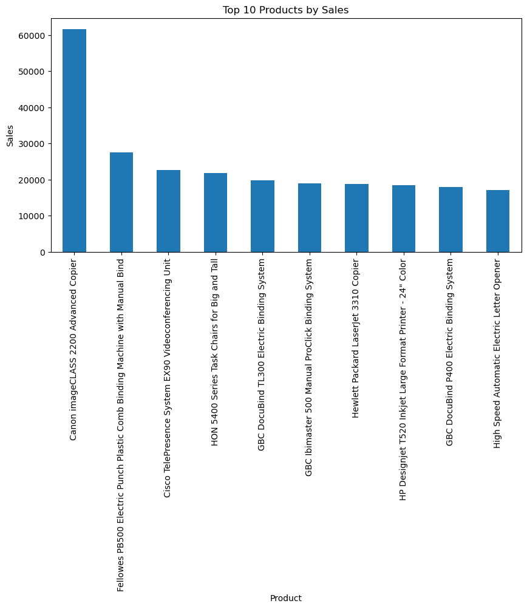

```python
plt.figure(figsize=(10,5))

top_products.plot(kind="bar")

plt.title("Top 10 Products by Sales")
plt.xlabel("Product")
plt.ylabel("Sales")

plt.show()
```

## Top Customers

Identifying high-value customers can help businesses design targeted marketing strategies.

### Customer Revenue Contribution

Retail businesses often rely on a small group of loyal customers who generate a significant share of total revenue. Identifying high-value customers helps companies focus their marketing efforts and improve customer retention strategies.

```python
top_customers = (
    df.groupby("customer_name")["sales"]
    .sum()
    .sort_values(ascending=False)
    .head(10)
)

top_customers
```

```
customer_name
Sean Miller           25043.07
Tamara Chand          19052.22
Raymond Buch          15117.35
Tom Ashbrook          14595.62
Adrian Barton         14473.57
Ken Lonsdale          14175.23
Sanjit Chand          14142.34
Hunter Lopez          12873.30
Sanjit Engle          12209.44
Christopher Conant    12129.08
Name: sales, dtype: float64
```

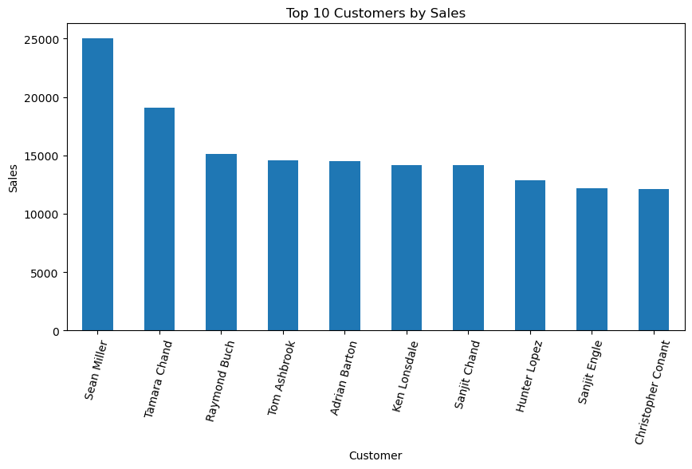

```python
plt.figure(figsize=(10,5))

top_customers.plot(kind="bar")

plt.title("Top 10 Customers by Sales")
plt.xlabel("Customer")
plt.ylabel("Sales")

plt.xticks(rotation=75)

plt.show()
```

## Profit vs Discount Analysis

### Impact of Discounts on Profitability

Discounting is commonly used in retail to drive sales. However, excessive discounts can significantly reduce profit margins. This analysis examines how discounts affect profitability across orders.

Understanding this relationship can help businesses balance revenue growth and profitability.

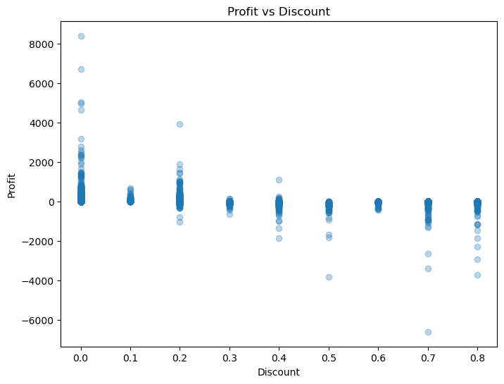

```python
plt.figure(figsize=(8,6))

plt.scatter(df["discount"], df["profit"], alpha=0.3)

plt.title("Profit vs Discount")
plt.xlabel("Discount")
plt.ylabel("Profit")

plt.show()
```

#### Insight

The scatter plot shows that higher discounts often lead to lower profits, and in many cases even negative profits. This suggests that aggressive discounting strategies may harm overall profitability and should be carefully managed.

## Shipping Delay Analysis

```python
df["shipping_time"] = (df["ship_date"] - df["order_date"]).dt.days

df["shipping_time"].describe()
```

```
count    9994.000000
mean        3.958175
std         1.747567
min         0.000000
25%         3.000000
50%         4.000000
75%         5.000000
max         7.000000
Name: shipping_time, dtype: float64
```

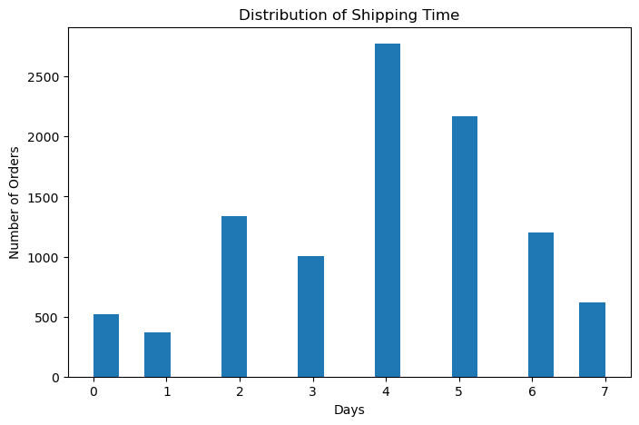

```python
plt.figure(figsize=(8,5))

df["shipping_time"].hist(bins=20)

plt.title("Distribution of Shipping Time")
plt.xlabel("Days")
plt.ylabel("Number of Orders")

plt.grid(False)
plt.show()
```

## Conclusion

This analysis explored sales performance, customer behavior, and product trends within an e-commerce dataset. The insights highlight the importance of regional market performance, customer segmentation, and product category management.

Businesses can leverage these insights to optimize marketing strategies, improve product offerings, and enhance customer targeting.